# Pima Indians Diabetes Database

### Predict the onset of diabetes based on diagnostic measure

#### Context

This dataset is originally from the National Institute of Diabetes and Digestive and Kidney Diseases. The objective of the dataset is to diagnostically predict whether or not a patient has diabetes, based on certain diagnostic measurements included in the dataset. Several constraints were placed on the selection of these instances from a larger database. In particular, all patients here are females at least 21 years old of Pima Indian heritage.

### Columns

```
* PregnanciesNumber of times pregnant
* GlucosePlasma glucose concentration a 2 hours in an oral glucose tolerance test
* BloodPressureDiastolic blood pressure (mm Hg)
* SkinThicknessTriceps skin fold thickness (mm)
* Insulin2-Hour serum insulin (mu U/ml)
* BMIBody mass index (weight in kg/(height in m)^2)
* DiabetesPedigreeFunctionDiabetes pedigree function
* AgeAge (years)
* OutcomeClass variable (0 or 1) 268 of 768 are 1, the others are 0
```

```python
import numpy as np
import pandas as pd
import seaborn as sns
import matplotlib.pyplot as plt
%matplotlib inline
```

```python
data = pd.read_csv('diabetes.csv')
```

```python
data.head()
```

|  | Pregnancies | Glucose | BloodPressure | SkinThickness | Insulin | BMI | DiabetesPedigreeFunction | Age | Outcome |
| --- | --- | --- | --- | --- | --- | --- | --- | --- | --- |
| 0 | 6 | 148 | 72 | 35 | 0 | 33.6 | 0.627 | 50 | 1 |
| 1 | 1 | 85 | 66 | 29 | 0 | 26.6 | 0.351 | 31 | 0 |
| 2 | 8 | 183 | 64 | 0 | 0 | 23.3 | 0.672 | 32 | 1 |
| 3 | 1 | 89 | 66 | 23 | 94 | 28.1 | 0.167 | 21 | 0 |
| 4 | 0 | 137 | 40 | 35 | 168 | 43.1 | 2.288 | 33 | 1 |

```python
data.isnull().values.any()
```

```
False
```

```python
data.isna().values.any()
```

```
False
```

```python
data.info()
```

```
<class 'pandas.core.frame.DataFrame'>
RangeIndex: 768 entries, 0 to 767
Data columns (total 9 columns):
Pregnancies                 768 non-null int64
Glucose                     768 non-null int64
BloodPressure               768 non-null int64
SkinThickness               768 non-null int64
Insulin                     768 non-null int64
BMI                         768 non-null float64
DiabetesPedigreeFunction    768 non-null float64
Age                         768 non-null int64
Outcome                     768 non-null int64
dtypes: float64(2), int64(7)
memory usage: 54.1 KB
```

```python
data.describe().transpose()
```

|  | count | mean | std | min | 25% | 50% | 75% | max |
| --- | --- | --- | --- | --- | --- | --- | --- | --- |
| Pregnancies | 768.0 | 3.845052 | 3.369578 | 0.000 | 1.00000 | 3.0000 | 6.00000 | 17.00 |
| Glucose | 768.0 | 120.894531 | 31.972618 | 0.000 | 99.00000 | 117.0000 | 140.25000 | 199.00 |
| BloodPressure | 768.0 | 69.105469 | 19.355807 | 0.000 | 62.00000 | 72.0000 | 80.00000 | 122.00 |
| SkinThickness | 768.0 | 20.536458 | 15.952218 | 0.000 | 0.00000 | 23.0000 | 32.00000 | 99.00 |
| Insulin | 768.0 | 79.799479 | 115.244002 | 0.000 | 0.00000 | 30.5000 | 127.25000 | 846.00 |
| BMI | 768.0 | 31.992578 | 7.884160 | 0.000 | 27.30000 | 32.0000 | 36.60000 | 67.10 |
| DiabetesPedigreeFunction | 768.0 | 0.471876 | 0.331329 | 0.078 | 0.24375 | 0.3725 | 0.62625 | 2.42 |
| Age | 768.0 | 33.240885 | 11.760232 | 21.000 | 24.00000 | 29.0000 | 41.00000 | 81.00 |
| Outcome | 768.0 | 0.348958 | 0.476951 | 0.000 | 0.00000 | 0.0000 | 1.00000 | 1.00 |

```python
cor = data.corr()
```

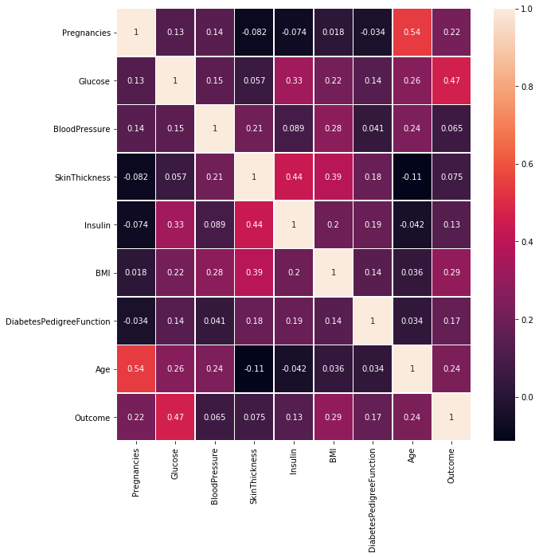

```python
fig, ax = plt.subplots(figsize=(10,10))
sns.heatmap(cor, annot=True , linewidths=.5, ax=ax)
```

From heatmap we conclude that as below:

```
1. Age and skinthickness have negative co related
2. Glucose is corelated to outcomes
3. Blood pressure, Skinthickness have small corelation
4. Blood pressure and insulin have very small corelation
5. Skinthickness have corelation with insulin and BMI
```

```python
data['Age'].mean()
```

```
33.240885416666664
```

### Outcomes from heatmap

1. SkinThickness is not corelated with outcomes
2. blood pressure is not corelated to outcomes

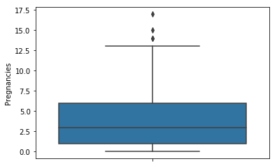

```python
sns.boxplot(y=data['Pregnancies'])
```

```python
data['Pregnancies'].mean()
```

```
3.8450520833333335
```

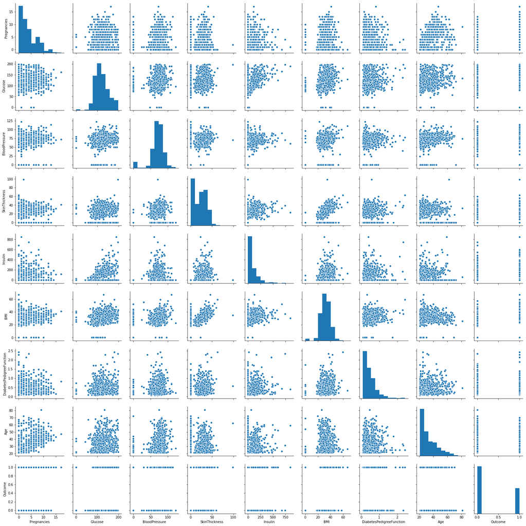

```python
sns.pairplot(data)
```

From Paireplot We conclude as below:

[output not shown]

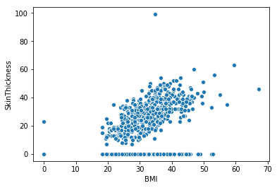

```python
sns.scatterplot(x='BMI',y='SkinThickness', data=data)
```

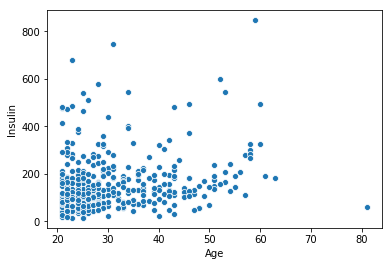

```python
sns.scatterplot(x='Age',y='Insulin', data=data[data.Insulin !=0])
```

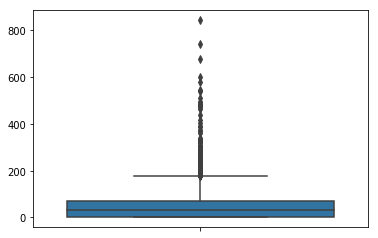

```python
sns.boxplot(y=data[data.Insulin !=0])
```

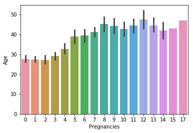

```python
sns.barplot(x='Pregnancies', y='Age', data=data)
```

```python
data['Pregnancies'].max()
```

```
17
```

```python
data['Age'].max()
```

```
81
```

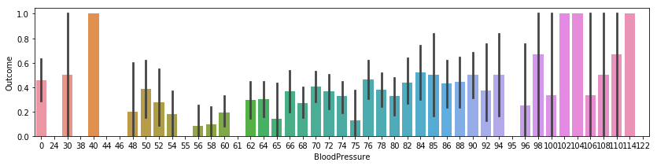

```python
plt.figure(figsize=(14,3))
sns.barplot(data.BloodPressure, data.Outcome)
```

### Blood Pressure

blood pressure can not be 0

```python
data[data.BloodPressure==0]['Age'].count()
```

```
35
```

Total 35 records with blood pressure = 0, so these are invalid entries

```python
data[data.BloodPressure==0].shape[0]
```

```
35
```

```python
data[data.BloodPressure==0].index.tolist()
```

```
[7,
 15,
 49,
 60,
 78,
 81,
 172,
 193,
 222,
 261,
 266,
 269,
 300,
 332,
 336,
 347,
 357,
 426,
 430,
 435,
 453,
 468,
 484,
 494,
 522,
 533,
 535,
 589,
 601,
 604,
 619,
 643,
 697,
 703,
 706]
```

```python
data[data.BloodPressure==0].groupby('Outcome')['Age'].count()
```

```
Outcome
0    19
1    16
Name: Age, dtype: int64
```

```python
data[data.Glucose==0]['Age'].count()
```

```
5
```

There is 5 entries for glucose have 0 value, which would not be 0. So these are invalid entries

```python
data[data.SkinThickness == 0]['Age'].count()
```

```
227
```

skinThickness could not be 0. so it is invalid entries

```python
data[data.BMI ==0]['Age'].count()
```

```
11
```

BMI could not be 0. So it is invalid records

```python
data[data.Insulin == 0]['Age'].count()
```

```
374
```

Insuline could not be 0

```python
data.info()
```

```
<class 'pandas.core.frame.DataFrame'>
RangeIndex: 768 entries, 0 to 767
Data columns (total 9 columns):
Pregnancies                 768 non-null int64
Glucose                     768 non-null int64
BloodPressure               768 non-null int64
SkinThickness               768 non-null int64
Insulin                     768 non-null int64
BMI                         768 non-null float64
DiabetesPedigreeFunction    768 non-null float64
Age                         768 non-null int64
Outcome                     768 non-null int64
dtypes: float64(2), int64(7)
memory usage: 54.1 KB
```

```python
mydata1 =data[data.BloodPressure!=0]
```

Remove data with BloodPressure lave 0

```python
mydata1.info()
```

```
<class 'pandas.core.frame.DataFrame'>
Int64Index: 733 entries, 0 to 767
Data columns (total 9 columns):
Pregnancies                 733 non-null int64
Glucose                     733 non-null int64
BloodPressure               733 non-null int64
SkinThickness               733 non-null int64
Insulin                     733 non-null int64
BMI                         733 non-null float64
DiabetesPedigreeFunction    733 non-null float64
Age                         733 non-null int64
Outcome                     733 non-null int64
dtypes: float64(2), int64(7)
memory usage: 57.3 KB
```

```python
mydata1 =data[data.BMI!=0]
mydata1.info()
```

```
<class 'pandas.core.frame.DataFrame'>
Int64Index: 757 entries, 0 to 767
Data columns (total 9 columns):
Pregnancies                 757 non-null int64
Glucose                     757 non-null int64
BloodPressure               757 non-null int64
SkinThickness               757 non-null int64
Insulin                     757 non-null int64
BMI                         757 non-null float64
DiabetesPedigreeFunction    757 non-null float64
Age                         757 non-null int64
Outcome                     757 non-null int64
dtypes: float64(2), int64(7)
memory usage: 59.1 KB
```

Remove data with BMI lave 0

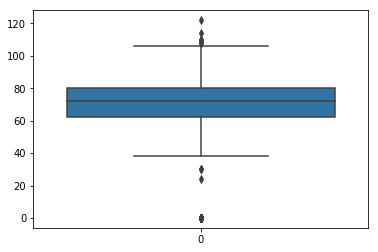

```python
sns.boxplot(data=data.BloodPressure)
```

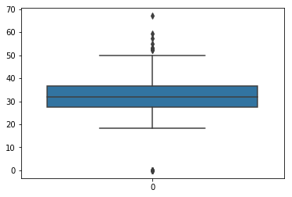

```python
sns.boxplot(data=data.BMI)
```

```python
data.info()
```

```
<class 'pandas.core.frame.DataFrame'>
RangeIndex: 768 entries, 0 to 767
Data columns (total 9 columns):
Pregnancies                 768 non-null int64
Glucose                     768 non-null int64
BloodPressure               768 non-null int64
SkinThickness               768 non-null int64
Insulin                     768 non-null int64
BMI                         768 non-null float64
DiabetesPedigreeFunction    768 non-null float64
Age                         768 non-null int64
Outcome                     768 non-null int64
dtypes: float64(2), int64(7)
memory usage: 54.1 KB
```

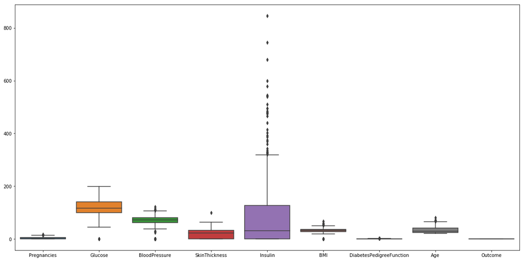

```python
plt.figure(figsize=(20,10))
sns.boxplot(data=data)
```

1. Insuline,Age is rightskewed
2. Skinthickness is left skewed

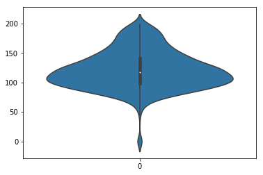

```python
sns.violinplot(data=data.Glucose)
```

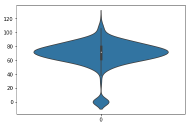

```python
sns.violinplot(data=data.BloodPressure)
```

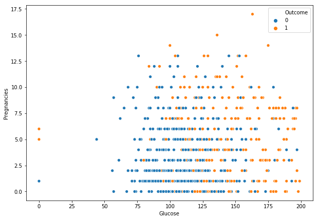

```python
plt.figure(figsize=(10,7))
sns.scatterplot(x ='Glucose', y='Pregnancies',hue ='Outcome',data=data)
```

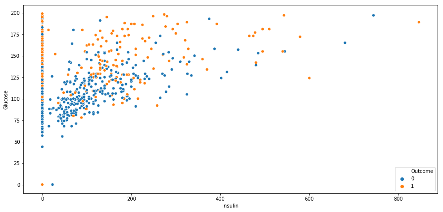

```python
plt.figure(figsize=(15,7))
sns.scatterplot(x ='Insulin', y='Glucose',hue ='Outcome',data=data)
```

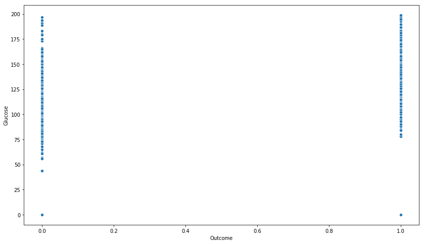

```python
plt.figure(figsize=(14,8))
sns.scatterplot(x ='Outcome', y='Glucose',data=data)
```

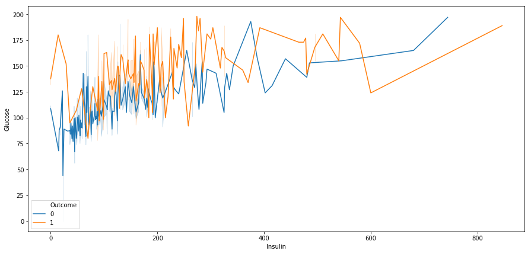

```python
plt.figure(figsize=(15,7))
sns.lineplot(x ='Insulin', y='Glucose',hue ='Outcome',data=data)
```

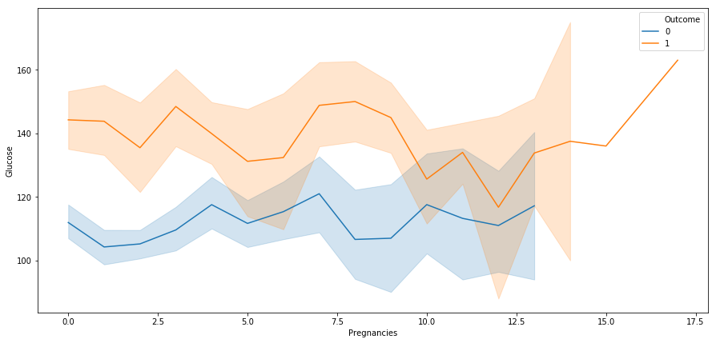

```python
plt.figure(figsize=(15,7))
sns.lineplot(x ='Pregnancies', y='Glucose',hue ='Outcome',data=data)
```

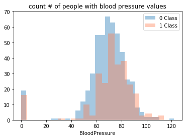

```python
sns.distplot(data[data.Outcome == 0]['BloodPressure'], kde=False, label='0 Class')
sns.distplot(data[data.Outcome == 1]['BloodPressure'], color='coral', kde=False, label='1 Class')
plt.legend()
plt.title('count # of people with blood pressure values')
```

```python
bp = data.groupby('BloodPressure').Outcome.count().reset_index()
```

```python
data.BloodPressure.unique()
```

```
array([ 72,  66,  64,  40,  74,  50,   0,  70,  96,  92,  80,  60,  84,
        30,  88,  90,  94,  76,  82,  75,  58,  78,  68, 110,  56,  62,
        85,  86,  48,  44,  65, 108,  55, 122,  54,  52,  98, 104,  95,
        46, 102, 100,  61,  24,  38, 106, 114], dtype=int64)
```

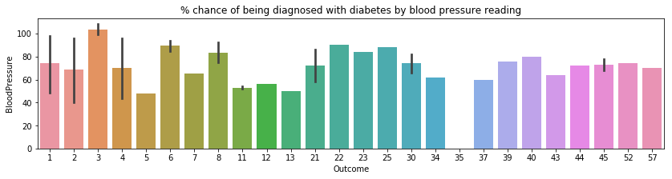

```python
plt.figure(figsize=(14,3))
sns.barplot(x=bp.Outcome,y=bp.BloodPressure)
plt.title('% chance of being diagnosed with diabetes by blood pressure reading')
```

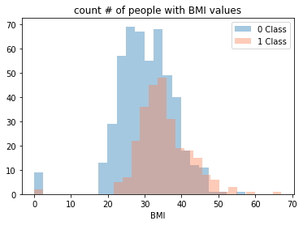

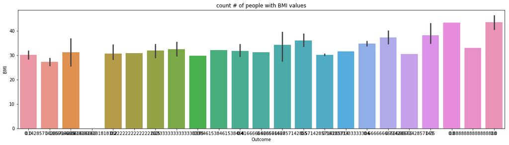

```python
sns.distplot(data[data.Outcome == 0]['BMI'], kde=False, label='0 Class')
sns.distplot(data[data.Outcome == 1]['BMI'], color='coral', kde=False, label='1 Class')
plt.legend()
plt.title('count # of people with BMI values')

plt.figure(figsize=(20,5))
dbmi = data.groupby('BMI').Outcome.mean().reset_index()
sns.barplot(x=dbmi.Outcome, y=dbmi.BMI)
plt.title('count # of people with BMI values')
```

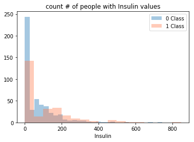

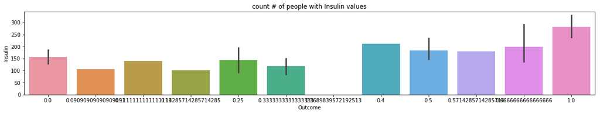

```python
sns.distplot(data[data.Outcome == 0]['Insulin'], kde=False, label='0 Class')
sns.distplot(data[data.Outcome == 1]['Insulin'], color='coral', kde=False, label='1 Class')
plt.legend()
plt.title('count # of people with Insulin values')

plt.figure(figsize=(20,3))
di = data.groupby('Insulin').Outcome.mean().reset_index()
sns.barplot(x=di.Outcome, y=di.Insulin)
plt.title('count # of people with Insulin values')
```